# Risk Factor Analysis

## Outcome Variable

**Outcome Variable:** ever_stunted

## Predictor Variables

**Intervention Variable:** predfeed6

**Adjustment Set:**

- arm
- sex
- month
- brthmon
- W_mage
- meducyrs
- feducyrs
- hhwealth_quart
- hfoodsec
- W_mhtcm
- W_mwtkg
- W_mbmi
- vagbrth
- W_gagebrth
- W_birthwt
- W_birthlen
- W_nrooms
- W_nchldlt5
- W_parity
- impfloor
- impsan
- safeh20
- delta_W_mage
- delta_meducyrs
- delta_feducyrs
- delta_hhwealth_quart
- delta_hfoodsec
- delta_W_mhtcm
- delta_W_mwtkg
- delta_W_mbmi
- delta_vagbrth
- delta_W_gagebrth
- delta_W_birthwt
- delta_W_birthlen
- delta_W_nrooms
- delta_W_nchldlt5
- delta_W_parity
- delta_impfloor
- delta_impsan
- delta_safeh20

## Stratifying Variables

The analysis was stratified on these variable(s):

- agecat
- studyid
- country

## Data Summary

| agecat | studyid | country | predfeed6 | ever_stunted | n_cell | n |
| --- | --- | --- | --- | --- | --- | --- |
| 0-24 months (no birth st.) | EE | PAKISTAN | 1 | 0 | 4 | 27 |
| 0-24 months (no birth st.) | EE | PAKISTAN | 1 | 1 | 19 | 27 |
| 0-24 months (no birth st.) | EE | PAKISTAN | 0 | 0 | 2 | 27 |
| 0-24 months (no birth st.) | EE | PAKISTAN | 0 | 1 | 2 | 27 |
| 0-24 months (no birth st.) | GMS-Nepal | NEPAL | 1 | 0 | 130 | 471 |
| 0-24 months (no birth st.) | GMS-Nepal | NEPAL | 1 | 1 | 222 | 471 |
| 0-24 months (no birth st.) | GMS-Nepal | NEPAL | 0 | 0 | 34 | 471 |
| 0-24 months (no birth st.) | GMS-Nepal | NEPAL | 0 | 1 | 85 | 471 |
| 0-24 months (no birth st.) | JiVitA-3 | BANGLADESH | 1 | 0 | 6247 | 10809 |
| 0-24 months (no birth st.) | JiVitA-3 | BANGLADESH | 1 | 1 | 2191 | 10809 |
| 0-24 months (no birth st.) | JiVitA-3 | BANGLADESH | 0 | 0 | 1776 | 10809 |
| 0-24 months (no birth st.) | JiVitA-3 | BANGLADESH | 0 | 1 | 595 | 10809 |
| 0-24 months (no birth st.) | JiVitA-4 | BANGLADESH | 1 | 0 | 1565 | 3397 |
| 0-24 months (no birth st.) | JiVitA-4 | BANGLADESH | 1 | 1 | 1125 | 3397 |
| 0-24 months (no birth st.) | JiVitA-4 | BANGLADESH | 0 | 0 | 393 | 3397 |
| 0-24 months (no birth st.) | JiVitA-4 | BANGLADESH | 0 | 1 | 314 | 3397 |
| 0-24 months (no birth st.) | LCNI-5 | MALAWI | 1 | 0 | 18 | 175 |
| 0-24 months (no birth st.) | LCNI-5 | MALAWI | 1 | 1 | 12 | 175 |
| 0-24 months (no birth st.) | LCNI-5 | MALAWI | 0 | 0 | 83 | 175 |
| 0-24 months (no birth st.) | LCNI-5 | MALAWI | 0 | 1 | 62 | 175 |
| 0-24 months (no birth st.) | MAL-ED | BANGLADESH | 1 | 0 | 32 | 195 |
| 0-24 months (no birth st.) | MAL-ED | BANGLADESH | 1 | 1 | 40 | 195 |
| 0-24 months (no birth st.) | MAL-ED | BANGLADESH | 0 | 0 | 58 | 195 |
| 0-24 months (no birth st.) | MAL-ED | BANGLADESH | 0 | 1 | 65 | 195 |
| 0-24 months (no birth st.) | MAL-ED | BRAZIL | 1 | 0 | 20 | 185 |
| 0-24 months (no birth st.) | MAL-ED | BRAZIL | 1 | 1 | 4 | 185 |
| 0-24 months (no birth st.) | MAL-ED | BRAZIL | 0 | 0 | 134 | 185 |
| 0-24 months (no birth st.) | MAL-ED | BRAZIL | 0 | 1 | 27 | 185 |
| 0-24 months (no birth st.) | MAL-ED | INDIA | 1 | 0 | 1 | 185 |
| 0-24 months (no birth st.) | MAL-ED | INDIA | 1 | 1 | 7 | 185 |

[output cut: 74 more lines]

The following strata were considered:

- agecat: 0-24 months (no birth st.), studyid: EE, country: PAKISTAN
- agecat: 0-24 months (no birth st.), studyid: GMS-Nepal, country: NEPAL
- agecat: 0-24 months (no birth st.), studyid: JiVitA-3, country: BANGLADESH
- agecat: 0-24 months (no birth st.), studyid: JiVitA-4, country: BANGLADESH
- agecat: 0-24 months (no birth st.), studyid: LCNI-5, country: MALAWI
- agecat: 0-24 months (no birth st.), studyid: MAL-ED, country: BANGLADESH
- agecat: 0-24 months (no birth st.), studyid: MAL-ED, country: BRAZIL
- agecat: 0-24 months (no birth st.), studyid: MAL-ED, country: INDIA
- agecat: 0-24 months (no birth st.), studyid: MAL-ED, country: NEPAL
- agecat: 0-24 months (no birth st.), studyid: MAL-ED, country: PERU
- agecat: 0-24 months (no birth st.), studyid: MAL-ED, country: SOUTH AFRICA
- agecat: 0-24 months (no birth st.), studyid: MAL-ED, country: TANZANIA, UNITED REPUBLIC OF
- agecat: 0-24 months (no birth st.), studyid: SAS-FoodSuppl, country: INDIA
- agecat: 0-6 months (no birth st.), studyid: EE, country: PAKISTAN
- agecat: 0-6 months (no birth st.), studyid: GMS-Nepal, country: NEPAL
- agecat: 0-6 months (no birth st.), studyid: JiVitA-3, country: BANGLADESH
- agecat: 0-6 months (no birth st.), studyid: JiVitA-4, country: BANGLADESH
- agecat: 0-6 months (no birth st.), studyid: LCNI-5, country: MALAWI
- agecat: 0-6 months (no birth st.), studyid: MAL-ED, country: BANGLADESH
- agecat: 0-6 months (no birth st.), studyid: MAL-ED, country: BRAZIL
- agecat: 0-6 months (no birth st.), studyid: MAL-ED, country: INDIA
- agecat: 0-6 months (no birth st.), studyid: MAL-ED, country: NEPAL
- agecat: 0-6 months (no birth st.), studyid: MAL-ED, country: PERU
- agecat: 0-6 months (no birth st.), studyid: MAL-ED, country: SOUTH AFRICA
- agecat: 0-6 months (no birth st.), studyid: MAL-ED, country: TANZANIA, UNITED REPUBLIC OF
- agecat: 0-6 months (no birth st.), studyid: SAS-FoodSuppl, country: INDIA

### Dropped Strata

Some strata were dropped due to rare outcomes:

- agecat: 0-24 months (no birth st.), studyid: EE, country: PAKISTAN
- agecat: 0-24 months (no birth st.), studyid: MAL-ED, country: BRAZIL
- agecat: 0-24 months (no birth st.), studyid: MAL-ED, country: INDIA
- agecat: 0-24 months (no birth st.), studyid: MAL-ED, country: SOUTH AFRICA
- agecat: 0-24 months (no birth st.), studyid: MAL-ED, country: TANZANIA, UNITED REPUBLIC OF
- agecat: 0-24 months (no birth st.), studyid: SAS-FoodSuppl, country: INDIA
- agecat: 0-6 months (no birth st.), studyid: EE, country: PAKISTAN
- agecat: 0-6 months (no birth st.), studyid: LCNI-5, country: MALAWI
- agecat: 0-6 months (no birth st.), studyid: MAL-ED, country: BRAZIL
- agecat: 0-6 months (no birth st.), studyid: MAL-ED, country: INDIA
- agecat: 0-6 months (no birth st.), studyid: MAL-ED, country: NEPAL
- agecat: 0-6 months (no birth st.), studyid: MAL-ED, country: SOUTH AFRICA
- agecat: 0-6 months (no birth st.), studyid: MAL-ED, country: TANZANIA, UNITED REPUBLIC OF
- agecat: 0-6 months (no birth st.), studyid: SAS-FoodSuppl, country: INDIA

## Methods Detail

We're interested in the causal parameters $E[Y_a]$ for all values of $a \in \mathcal{A}$. These parameters represent the mean outcome if, possibly contrary to fact, we intervened to set all units to have $A=a$. Under the randomization and positivity assumptions, these are identified by the statistical parameters $\psi_a=E_W[E_{Y|A,W}(Y|A=a,W)]$. In addition, we're interested in the mean of $Y$, $E[Y]$ under no intervention (the observed mean). We will estimate these parameters by using SuperLearner to fit the relevant likelihood factors -- $E_{Y|A,W}(Y|A=a,W)$ and $p(A=a|W)$, and then updating our likelihood fit using a joint TMLE.

For unadjusted analyses ($W=\{\}$), initial likelihoods were estimated using Lrnr_glm to estimate the simple $E(Y|A)$ and Lrnr_mean to estimate $p(A)$. For adjusted analyses, a small library containing Lrnr_glmnet, Lrnr_xgboost, and Lrnr_mean was used.

Having estimated these parameters, we will then use the delta method to estimate relative risks and attributable risks relative to a prespecified baseline level of $A$.

# Results Detail

## Results Plots

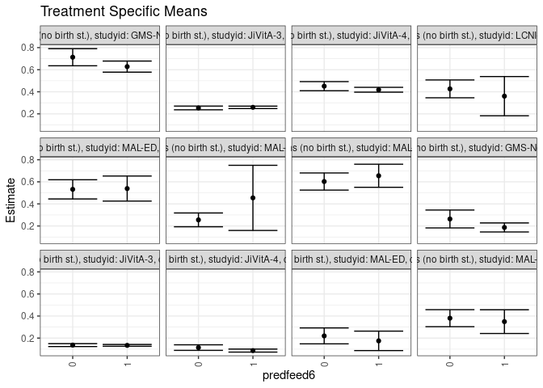

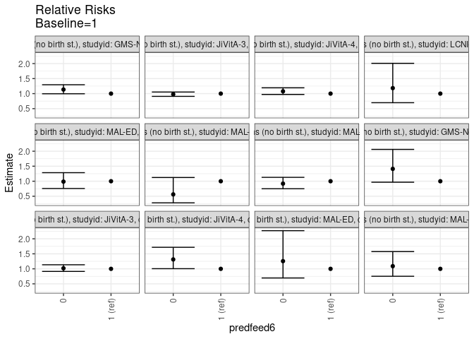

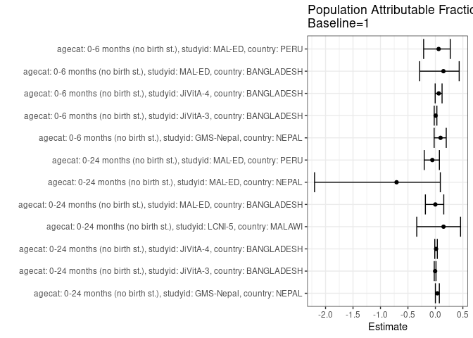

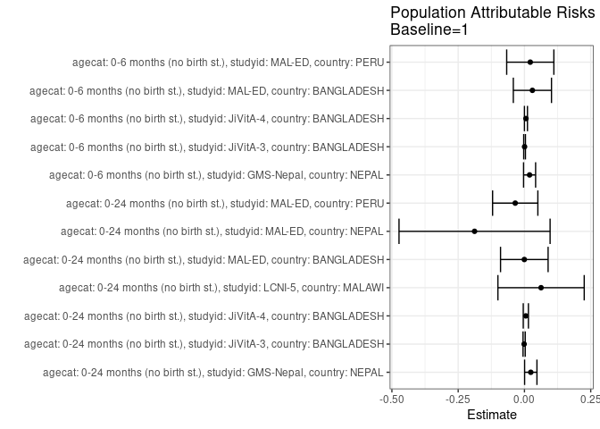

## Results Table

### Parameter: TSM

| agecat | studyid | country | intervention_level | baseline_level | estimate | ci_lower | ci_upper |
| --- | --- | --- | --- | --- | --- | --- | --- |
| 0-24 months (no birth st.) | GMS-Nepal | NEPAL | 1 | NA | 0.6279581 | 0.5777145 | 0.6782018 |
| 0-24 months (no birth st.) | GMS-Nepal | NEPAL | 0 | NA | 0.7131016 | 0.6356520 | 0.7905512 |
| 0-24 months (no birth st.) | JiVitA-3 | BANGLADESH | 1 | NA | 0.2589604 | 0.2479192 | 0.2700017 |
| 0-24 months (no birth st.) | JiVitA-3 | BANGLADESH | 0 | NA | 0.2534253 | 0.2364818 | 0.2703689 |
| 0-24 months (no birth st.) | JiVitA-4 | BANGLADESH | 1 | NA | 0.4184076 | 0.3965046 | 0.4403106 |
| 0-24 months (no birth st.) | JiVitA-4 | BANGLADESH | 0 | NA | 0.4506911 | 0.4094530 | 0.4919291 |
| 0-24 months (no birth st.) | LCNI-5 | MALAWI | 1 | NA | 0.3601963 | 0.1823677 | 0.5380248 |
| 0-24 months (no birth st.) | LCNI-5 | MALAWI | 0 | NA | 0.4262308 | 0.3453702 | 0.5070913 |
| 0-24 months (no birth st.) | MAL-ED | BANGLADESH | 1 | NA | 0.5389554 | 0.4254262 | 0.6524846 |
| 0-24 months (no birth st.) | MAL-ED | BANGLADESH | 0 | NA | 0.5318780 | 0.4448411 | 0.6189150 |
| 0-24 months (no birth st.) | MAL-ED | NEPAL | 1 | NA | 0.4545455 | 0.1595511 | 0.7495398 |
| 0-24 months (no birth st.) | MAL-ED | NEPAL | 0 | NA | 0.2553191 | 0.1928321 | 0.3178062 |
| 0-24 months (no birth st.) | MAL-ED | PERU | 1 | NA | 0.6550519 | 0.5505807 | 0.7595230 |
| 0-24 months (no birth st.) | MAL-ED | PERU | 0 | NA | 0.6027607 | 0.5251629 | 0.6803586 |
| 0-6 months (no birth st.) | GMS-Nepal | NEPAL | 1 | NA | 0.1865689 | 0.1456611 | 0.2274768 |
| 0-6 months (no birth st.) | GMS-Nepal | NEPAL | 0 | NA | 0.2633462 | 0.1822613 | 0.3444312 |
| 0-6 months (no birth st.) | JiVitA-3 | BANGLADESH | 1 | NA | 0.1342225 | 0.1259907 | 0.1424543 |
| 0-6 months (no birth st.) | JiVitA-3 | BANGLADESH | 0 | NA | 0.1367615 | 0.1237805 | 0.1497425 |
| 0-6 months (no birth st.) | JiVitA-4 | BANGLADESH | 1 | NA | 0.0869604 | 0.0733774 | 0.1005433 |
| 0-6 months (no birth st.) | JiVitA-4 | BANGLADESH | 0 | NA | 0.1142080 | 0.0890237 | 0.1393922 |
| 0-6 months (no birth st.) | MAL-ED | BANGLADESH | 1 | NA | 0.1751234 | 0.0870066 | 0.2632402 |
| 0-6 months (no birth st.) | MAL-ED | BANGLADESH | 0 | NA | 0.2200312 | 0.1480578 | 0.2920047 |
| 0-6 months (no birth st.) | MAL-ED | PERU | 1 | NA | 0.3493420 | 0.2417805 | 0.4569036 |
| 0-6 months (no birth st.) | MAL-ED | PERU | 0 | NA | 0.3804704 | 0.3034523 | 0.4574885 |

### Parameter: E(Y)

| agecat | studyid | country | intervention_level | baseline_level | estimate | ci_lower | ci_upper |
| --- | --- | --- | --- | --- | --- | --- | --- |
| 0-24 months (no birth st.) | GMS-Nepal | NEPAL | NA | NA | 0.6518047 | 0.6087352 | 0.6948741 |
| 0-24 months (no birth st.) | JiVitA-3 | BANGLADESH | NA | NA | 0.2577482 | 0.2478575 | 0.2676389 |
| 0-24 months (no birth st.) | JiVitA-4 | BANGLADESH | NA | NA | 0.4236091 | 0.4038600 | 0.4433581 |
| 0-24 months (no birth st.) | LCNI-5 | MALAWI | NA | NA | 0.4228571 | 0.3494545 | 0.4962598 |
| 0-24 months (no birth st.) | MAL-ED | BANGLADESH | NA | NA | 0.5384615 | 0.4683114 | 0.6086117 |
| 0-24 months (no birth st.) | MAL-ED | NEPAL | NA | NA | 0.2663317 | 0.2047606 | 0.3279027 |
| 0-24 months (no birth st.) | MAL-ED | PERU | NA | NA | 0.6202532 | 0.5583342 | 0.6821721 |
| 0-6 months (no birth st.) | GMS-Nepal | NEPAL | NA | NA | 0.2059448 | 0.1693853 | 0.2425043 |
| 0-6 months (no birth st.) | JiVitA-3 | BANGLADESH | NA | NA | 0.1346474 | 0.1274032 | 0.1418916 |
| 0-6 months (no birth st.) | JiVitA-4 | BANGLADESH | NA | NA | 0.0926091 | 0.0806150 | 0.1046031 |
| 0-6 months (no birth st.) | MAL-ED | BANGLADESH | NA | NA | 0.2051282 | 0.1483073 | 0.2619492 |
| 0-6 months (no birth st.) | MAL-ED | PERU | NA | NA | 0.3713080 | 0.3096658 | 0.4329502 |

### Parameter: RR

| agecat | studyid | country | intervention_level | baseline_level | estimate | ci_lower | ci_upper |
| --- | --- | --- | --- | --- | --- | --- | --- |
| 0-24 months (no birth st.) | GMS-Nepal | NEPAL | 1 | 1 | 1.0000000 | 1.0000000 | 1.000000 |
| 0-24 months (no birth st.) | GMS-Nepal | NEPAL | 0 | 1 | 1.1355878 | 0.9948636 | 1.296218 |
| 0-24 months (no birth st.) | JiVitA-3 | BANGLADESH | 1 | 1 | 1.0000000 | 1.0000000 | 1.000000 |
| 0-24 months (no birth st.) | JiVitA-3 | BANGLADESH | 0 | 1 | 0.9786257 | 0.9091030 | 1.053465 |
| 0-24 months (no birth st.) | JiVitA-4 | BANGLADESH | 1 | 1 | 1.0000000 | 1.0000000 | 1.000000 |
| 0-24 months (no birth st.) | JiVitA-4 | BANGLADESH | 0 | 1 | 1.0771579 | 0.9724557 | 1.193133 |
| 0-24 months (no birth st.) | LCNI-5 | MALAWI | 1 | 1 | 1.0000000 | 1.0000000 | 1.000000 |
| 0-24 months (no birth st.) | LCNI-5 | MALAWI | 0 | 1 | 1.1833292 | 0.6970172 | 2.008943 |
| 0-24 months (no birth st.) | MAL-ED | BANGLADESH | 1 | 1 | 1.0000000 | 1.0000000 | 1.000000 |
| 0-24 months (no birth st.) | MAL-ED | BANGLADESH | 0 | 1 | 0.9868683 | 0.7583316 | 1.284279 |
| 0-24 months (no birth st.) | MAL-ED | NEPAL | 1 | 1 | 1.0000000 | 1.0000000 | 1.000000 |
| 0-24 months (no birth st.) | MAL-ED | NEPAL | 0 | 1 | 0.5617021 | 0.2807235 | 1.123915 |
| 0-24 months (no birth st.) | MAL-ED | PERU | 1 | 1 | 1.0000000 | 1.0000000 | 1.000000 |
| 0-24 months (no birth st.) | MAL-ED | PERU | 0 | 1 | 0.9201725 | 0.7496238 | 1.129523 |
| 0-6 months (no birth st.) | GMS-Nepal | NEPAL | 1 | 1 | 1.0000000 | 1.0000000 | 1.000000 |
| 0-6 months (no birth st.) | GMS-Nepal | NEPAL | 0 | 1 | 1.4115224 | 0.9672808 | 2.059790 |
| 0-6 months (no birth st.) | JiVitA-3 | BANGLADESH | 1 | 1 | 1.0000000 | 1.0000000 | 1.000000 |
| 0-6 months (no birth st.) | JiVitA-3 | BANGLADESH | 0 | 1 | 1.0189165 | 0.9140984 | 1.135754 |
| 0-6 months (no birth st.) | JiVitA-4 | BANGLADESH | 1 | 1 | 1.0000000 | 1.0000000 | 1.000000 |
| 0-6 months (no birth st.) | JiVitA-4 | BANGLADESH | 0 | 1 | 1.3133334 | 1.0048510 | 1.716518 |
| 0-6 months (no birth st.) | MAL-ED | BANGLADESH | 1 | 1 | 1.0000000 | 1.0000000 | 1.000000 |
| 0-6 months (no birth st.) | MAL-ED | BANGLADESH | 0 | 1 | 1.2564357 | 0.6953176 | 2.270373 |
| 0-6 months (no birth st.) | MAL-ED | PERU | 1 | 1 | 1.0000000 | 1.0000000 | 1.000000 |
| 0-6 months (no birth st.) | MAL-ED | PERU | 0 | 1 | 1.0891056 | 0.7529357 | 1.575368 |

### Parameter: PAR

| agecat | studyid | country | intervention_level | baseline_level | estimate | ci_lower | ci_upper |
| --- | --- | --- | --- | --- | --- | --- | --- |
| 0-24 months (no birth st.) | GMS-Nepal | NEPAL | 1 | NA | 0.0238465 | 0.0005669 | 0.0471262 |
| 0-24 months (no birth st.) | JiVitA-3 | BANGLADESH | 1 | NA | -0.0012123 | -0.0053297 | 0.0029052 |
| 0-24 months (no birth st.) | JiVitA-4 | BANGLADESH | 1 | NA | 0.0052014 | -0.0045489 | 0.0149517 |
| 0-24 months (no birth st.) | LCNI-5 | MALAWI | 1 | NA | 0.0626609 | -0.1001172 | 0.2254389 |
| 0-24 months (no birth st.) | MAL-ED | BANGLADESH | 1 | NA | -0.0004939 | -0.0902125 | 0.0892247 |
| 0-24 months (no birth st.) | MAL-ED | NEPAL | 1 | NA | -0.1882138 | -0.4731562 | 0.0967286 |
| 0-24 months (no birth st.) | MAL-ED | PERU | 1 | NA | -0.0347987 | -0.1201485 | 0.0505511 |
| 0-6 months (no birth st.) | GMS-Nepal | NEPAL | 1 | NA | 0.0193759 | -0.0033531 | 0.0421048 |
| 0-6 months (no birth st.) | JiVitA-3 | BANGLADESH | 1 | NA | 0.0004249 | -0.0028225 | 0.0036723 |
| 0-6 months (no birth st.) | JiVitA-4 | BANGLADESH | 1 | NA | 0.0056487 | -0.0000593 | 0.0113568 |
| 0-6 months (no birth st.) | MAL-ED | BANGLADESH | 1 | NA | 0.0300048 | -0.0419779 | 0.1019875 |
| 0-6 months (no birth st.) | MAL-ED | PERU | 1 | NA | 0.0219660 | -0.0670161 | 0.1109480 |

### Parameter: PAF

| agecat | studyid | country | intervention_level | baseline_level | estimate | ci_lower | ci_upper |
| --- | --- | --- | --- | --- | --- | --- | --- |
| 0-24 months (no birth st.) | GMS-Nepal | NEPAL | 1 | NA | 0.0365854 | -0.0000442 | 0.0718733 |
| 0-24 months (no birth st.) | JiVitA-3 | BANGLADESH | 1 | NA | -0.0047032 | -0.0207905 | 0.0111305 |
| 0-24 months (no birth st.) | JiVitA-4 | BANGLADESH | 1 | NA | 0.0122789 | -0.0110078 | 0.0350292 |
| 0-24 months (no birth st.) | LCNI-5 | MALAWI | 1 | NA | 0.1481845 | -0.3393807 | 0.4582648 |
| 0-24 months (no birth st.) | MAL-ED | BANGLADESH | 1 | NA | -0.0009172 | -0.1822096 | 0.1525739 |
| 0-24 months (no birth st.) | MAL-ED | NEPAL | 1 | NA | -0.7066895 | -2.2000739 | 0.0897744 |
| 0-24 months (no birth st.) | MAL-ED | PERU | 1 | NA | -0.0561040 | -0.2033288 | 0.0731082 |
| 0-6 months (no birth st.) | GMS-Nepal | NEPAL | 1 | NA | 0.0940828 | -0.0226714 | 0.1975076 |
| 0-6 months (no birth st.) | JiVitA-3 | BANGLADESH | 1 | NA | 0.0031558 | -0.0212744 | 0.0270016 |
| 0-6 months (no birth st.) | JiVitA-4 | BANGLADESH | 1 | NA | 0.0609952 | -0.0037380 | 0.1215537 |
| 0-6 months (no birth st.) | MAL-ED | BANGLADESH | 1 | NA | 0.1462736 | -0.2864529 | 0.4334431 |
| 0-6 months (no birth st.) | MAL-ED | PERU | 1 | NA | 0.0591584 | -0.2138605 | 0.2707704 |